# 7. Linear algebra

## Python에서의 선형 대수

- 이 단원에서는 선형 대수의 여러 개념을 Python 기본 함수와 리스트 등을 이용하여 구현하는 연습을 한다.
- 벡터를 생성하고, 벡터와 행렬 연산을 수행할 수 있는 함수를 작성한다.
- 이 후, Python 모듈인 numpy를 이용하여 직접 만들었던 선형 대수의 기능과 비교해 본다.

### 벡터 - Vectors

- 벡터는 벡터 공간의 원소를 벡터라 하며,
- 백터들은 서로 더하거나 스칼라에 의해 곱해질 수 있다.
- 벡터를 숫자들의 리스트라고 생각해 보자.

```python
height_weigth_age = [70,    # inches
                    170,    # pounds
                    40 ]    # years
```

```python
grades = [95,    # exam1
          80,    # exam2
          75,    # exam3
          62 ]   # exam4
```

- Python의 list는 벡터 연산을 제공하지 않기 때문에, 벡터 연산을 추가해 보자.

### 벡터 합과 차

- 원소별로 계산 : 다음을 구현하고 싶음
  - [1, 2] 더하기 [3, 4] = [4, 6]
  - [5, 3] 빼기 [1, 7] = [4, -4]

```python
def vector_add(v, w):
    """adds two vectors componentwise"""
    return [v_i + w_i for v_i, w_i in zip(v,w)]
```

```python
vector_add([1,2], [3,4])
```

```
[4, 6]
```

```python
vector_add([1,2,3], [3,4,5])
```

```
[4, 6, 8]
```

```python
v = [1, 2, 3]
w = [2, 3, 4]
z = vector_add(v, w)
y = vector_add(z, v)
print(y)
```

```
[4, 7, 10]
```

```python
def vector_subtract(v, w):
    """subtracts two vectors componentwise"""
    return [v_i - w_i for v_i, w_i in zip(v,w)]
```

```python
vector_subtract([0, 0, 1], [1, 2, 3])
```

```
[-1, -2, -2]
```

### 여러 개의 벡터들의 합

- 벡터들의 리스트가 있을 때, 리스트 내의 벡터들을 원소 별로 합하기

```python
def vector_sum(vectors):
    result = vectors[0]
    for vector in vectors[1:]:
        result = vector_add(result, vector)
    return result
```

```python
vectors = [[1, 2, 3],
           [2, 3, 0],
           [0, 1, -2]]

vector_sum(vectors)
```

```
[3, 6, 1]
```

```python
from functools import reduce
# 앞의 vector_sum과 같은 기능을 가진다.
def vector_sum(vectors):
    return reduce(vector_add, vectors)
```

```python
vectors = [[1, 2, 3],
           [2, 3, 0],
           [0, 1, -2]]

vector_sum(vectors)
```

```
[3, 6, 1]
```

```python
# 내부적으로는 다음과 동치
vector_add(vector_add([1, 2, 3], [2, 3, 0]), [0, 1, -2])
```

```
[3, 6, 1]
```

### 스칼라 곱

- 목표 : 3*[1, 2, 3] = [3, 6, 9]

```python
def scalar_multiply(c, v):
    return [c * vi for vi in v]
```

```python
scalar_multiply(3, [1, 2, 3])
```

```
[3, 6, 9]
```

- 컴포넌트별 평균 : `vector_mean([1, 2], [2, 4], [3, 6]) == [2, 4]`

```python
def vector_mean(vectors):
    n = len(vectors)
    return scalar_multiply(1/n, vector_sum(vectors))
```

```python
vector_mean([[1, 2], [2, 4], [3, 6]])
```

```
[2.0, 4.0]
```

- 단, Python 2.x의 경우 위의 나누기에 실수 나누기를 적용하기 위해서는 파일 위쪽에 다음을 표기
  - Python 3.x는 실수 나누기가 적용되기 때문에 상관 없음

```python
from __future__ import division
```

### dot product

- 목표 :
  - dot( [1, 2, 3], [0, 1, 2]) = sum([1 * 0, 2 * 1, 3 * 2]) = sum([0, 2, 6]) = 8

```python
def dot(v, w):
    """v_1 * w_1 + ... + v_n * w_n"""
    return sum(v_i * w_i for v_i, w_i in zip(v, w))
```

```python
dot([1, 2, 3], [0, 1, 2])
```

```
8
```

### 제곱합

- 벡터 원소들의 제곱의 합

```python
def sum_of_squares(v):
    """v_1 * v_1 + ... + v_n * v_n"""
    return dot(v, v)
```

```python
sum_of_squares([0, 1, 2])
```

```
5
```

- 벡터의 크기(magnitude) : 제곱합의 제곱근

```python
import math
def magnitude(v):
    return math.sqrt(sum_of_squares(v))
```

```python
magnitude([3, 4])
```

```
5.0
```

```python
magnitude([5, 12])
```

```
13.0
```

### 벡터 사이의 거리

- 한 벡터에서 다른 벡터를 뺀 후, 크기를 구하는 것과 동일

```python
def distance(v, w):
    return magnitude(vector_subtract(v, w))
```

```python
distance([1, 2], [2, 3])
```

```
1.4142135623730951
```

## NumPy

- NumPy는 Python에서의 수학/과학 컴퓨팅의 기본 패키지로서
- numpy 모듈에는 지금까지 행한 벡터 연산들이 구현되어 있음.
- numpy 패키지 (모듈)는 Python을 사용하는 거의 모든 수치 계산에 사용된다.
- Python을 위한 벡터, 행렬 및 고차원 데이터 구조를 제공한다.
- http://www.numpy.org/

`numpy` 모듈을 이용하기 위해서는 다음과 같이 `import`를 먼저 진행한다. 시작 시 한 번만 불러오면 된다.

```python
import numpy as np
```

다음은 dot product 예제이다.

```python
# dot product
np.dot([1,2], [3,4])
```

```
11
```

### Numpy array

- numpy의 다양한 기능은 array라는 데이터구조를 바탕으로 이루어진다.
  - 효율적이고 계산이 편리함
- numpy array는 다양한 방법을 통해 만들 수 있다.
  - 파이썬 리스트 또는 튜플을 이용하는 방법
  - `arange`, `linspace` 등과 같이 numpy 배열을 생성하는 데 사용되는 함수를 사용하는 방법
  - 파일에서 데이터를 읽어들이는 방법
- 다차원 배열을 구현
- 수학적 계산에 특화

#### Python list로부터 numpy array 만들기

```python
import numpy as np  # 이미 한 번 import하였으면 다시 하지 않아도 된다.
a = np.array([0, 1, 2, 3])

a
```

```
array([0, 1, 2, 3])
```

```python
print(a)
```

```
[0 1 2 3]
```

```python
a.ndim  # 1 차원
```

```
1
```

```python
a.shape  # 형태 : (4,)
```

```
(4,)
```

```python
len(a)  # 4
```

```
4
```

```python
# matrix: Python list로 이루어진 list를 이용하여 matrix 만들기
b = np.array([[0,1,2], [3,4,5]])

b
```

```
array([[0, 1, 2],
       [3, 4, 5]])
```

```python
b.ndim  # 2차원
```

```
2
```

```python
b.shape # 형태 (2,3)
```

```
(2, 3)
```

```python
len(b)  # 2 : 첫번째 차원의 길이
```

```
2
```

array는 list와 비슷해 보이지만, numpy에서 array라는 별도의 데이터구조를 이용하는 몇 가지 이유가 있다.

- Python list는 동적으로 할당되며, list내의 원소들이 서로 다른 데이터형을 가질 수 있다.
- 이러한 점은 벡터나 행렬 계산을 느리게 혹은 불가능하게 한다.
- 반면 numpy array내의 원소들의 데이터 형은 일정하고(homogeneous), 변하지 않기 때문에, 메모리 효율적이고, 행렬이나 벡터 계산을 빠르게 할 수 있다.
- 이미 데이터 타입이 결정된 array의 원소를 다른 데이터 타입으로 변경하면 에러가 발생한다.

```python
b.dtype
```

```
dtype('int32')
```

```python
b[0,0] = "a"
```

```
---------------------------------------------------------------------------
ValueError                                Traceback (most recent call last)
<ipython-input-40-9c6a29519c7a> in <module>
----> 1 b[0,0] = "a"

ValueError: invalid literal for int() with base 10: 'a'
```

#### array 생성

numpy에서는 다양한 방법을 통해 array를 생성할 수 있도록 도와준다.

```python
a = np.arange(10)  # range 함수와 비슷

a
```

```
array([0, 1, 2, 3, 4, 5, 6, 7, 8, 9])
```

```python
b = np.arange(1, 9, 2)

b
```

```
array([1, 3, 5, 7])
```

```python
c = np.linspace(0, 1, 6)  #시작, 끝, 숫자 개수

c
```

```
array([0. , 0.2, 0.4, 0.6, 0.8, 1. ])
```

```python
d = np.ones((3, 3))  # 1로 이루어진 다차원 배열

d
```

```
array([[1., 1., 1.],
       [1., 1., 1.],
       [1., 1., 1.]])
```

```python
e = np.zeros((2, 2))  # 0으로 이루어진 다차원 배열

e
```

```
array([[0., 0.],
       [0., 0.]])
```

```python
f = np.eye(3)  # identity 행렬

f
```

```
array([[1., 0., 0.],
       [0., 1., 0.],
       [0., 0., 1.]])
```

```python
g = np.diag(np.array([1, 2, 3, 4]))  # 대각 행렬

g
```

```
array([[1, 0, 0, 0],
       [0, 2, 0, 0],
       [0, 0, 3, 0],
       [0, 0, 0, 4]])
```

```python
h = np.array(range(15)).reshape(3,5)

h
```

```
array([[ 0,  1,  2,  3,  4],
       [ 5,  6,  7,  8,  9],
       [10, 11, 12, 13, 14]])
```

#### array 생성(2)

numpy.random 모듈을 이용한 랜덤 array 생성

```python
np.random.rand(4)       # uniform in [0, 1]
```

```
array([0.58760612, 0.33940918, 0.08334586, 0.50487104])
```

```python
np.random.randn(4)      # standard normal
```

```
array([ 1.21036296, -0.39189033, -0.34292625,  0.43452542])
```

```python
2.5 * np.random.randn(4) + 3   # 평균 3, 표준편차 2.5인 정규분포
```

```
array([ 4.47487228,  4.29542421,  2.80871471, -1.36554071])
```

Python의 기본 random 모듈에서도 비슷한 기능을 수행하나, numpy.random 모듈을 이용하는 것이 속도가 빠르다.

```python
import random
N = 1000000
```

`%timeit`은 jupyter line magic 중의 하나로 실행시간을 측정할 수 있다.  
아래 두 실험의 결과를 비교하면 numpy.random모듈을 이용하는 것이 훨씬 빠름을 알 수 있다.

```python
%timeit sample1 = [random.random() for _ in range(N)]
```

```
163 ms ± 3.82 ms per loop (mean ± std. dev. of 7 runs, 10 loops each)
```

```python
%timeit sample2 = np.random.rand(N)
```

```
11.5 ms ± 168 µs per loop (mean ± std. dev. of 7 runs, 100 loops each)
```

위 예제들에서 경우에 따라 마침표 (예 : 2. vs 2)가 표시된다는 것을 알 수 있다. 이는 데이터 유형의 차이 때문이다. 마침표가 없는 것은 정수형 데이터, 마침표가 있는 것은 실수형 데이터를 의미한다. numpy array는 한 종류의 데이터 유형만 가질 수 있다.

#### Basic Slicing and Indexing

- Python list와 비슷하게 [ ]를 이용하여 원소에 접근한다.
- slicing 또한 Python list와 마찬가지로 `start:stop:step`를 이용한다.

```python
v = np.array([1, 2, 3, 4, 5, 6])
v
```

```
array([1, 2, 3, 4, 5, 6])
```

```python
v[0]
```

```
1
```

```python
v[2], v[-1]  # -1은 마지막 원소
```

```
(3, 6)
```

```python
v[1:5:2]
```

```
array([2, 4])
```

```python
v[::-1]  # 순서 뒤집기
```

```
array([6, 5, 4, 3, 2, 1])
```

2차원 array에서는 행(row)과 열(column)의 인덱스에 기반한다.

```python
M = np.array([[1, 2], [3, 4]])
M
```

```
array([[1, 2],
       [3, 4]])
```

```python
M[1, 1]
```

```
4
```

```python
# 인덱스 하나만 사용하면 하나의 행을 슬라이싱
M[1]  # row 1
```

```
array([3, 4])
```

```python
M[1, :] # row 1 (여기서 :는 모든 열을 의미)
```

```
array([3, 4])
```

```python
M[:, 1] # column 1 (여기서 :는 모든 행을 의미)
```

```
array([2, 4])
```

```python
M[0, 0] = 10

M
```

```
array([[10,  2],
       [ 3,  4]])
```

대입 연산도 마찬가지로 이루어질 수 있다.

```python
M[1, :] = -1

M
```

```
array([[10,  2],
       [-1, -1]])
```

```python
M[:, 1] = 777

M
```

```
array([[ 10, 777],
       [ -1, 777]])
```

```python
a = np.array([[n + m * 10 for n in range(6)] for m in range(6)])

a
```

```
array([[ 0,  1,  2,  3,  4,  5],
       [10, 11, 12, 13, 14, 15],
       [20, 21, 22, 23, 24, 25],
       [30, 31, 32, 33, 34, 35],
       [40, 41, 42, 43, 44, 45],
       [50, 51, 52, 53, 54, 55]])
```

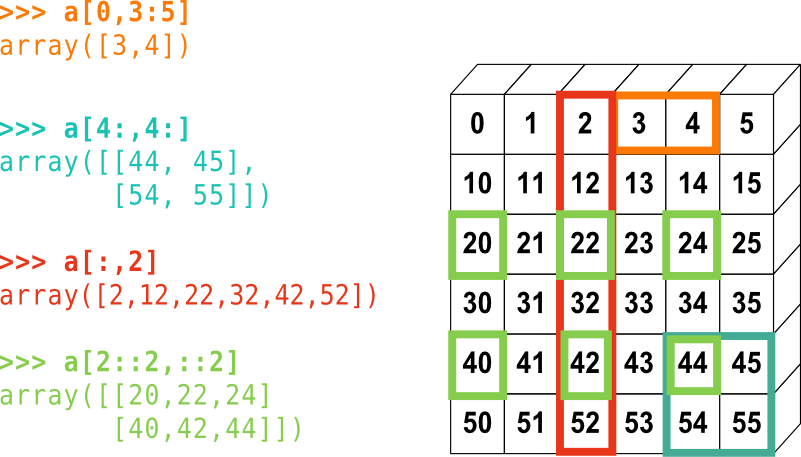

https://scipy-lectures.org/intro/numpy/array_object.html#what-are-numpy-and-numpy-arrays

```python
a[0, 3:5]
```

```
array([3, 4])
```

```python
a[4:, 4:]
```

```
array([[44, 45],
       [54, 55]])
```

```python
a[:, 2]
```

```
array([ 2, 12, 22, 32, 42, 52])
```

```python
a[2::2, ::2]
```

```
array([[20, 22, 24],
       [40, 42, 44]])
```

```python
a[1:3, 1:3]
```

```
array([[11, 12],
       [21, 22]])
```

```python
a[::2, ::2]
```

```
array([[ 0,  2,  4],
       [20, 22, 24],
       [40, 42, 44]])
```

#### Advanced Indexing

`:`를 이용하는 slicing이 아닌 정수 혹은 Boolean의 list, array, tuple 등으로 이루어진 indexing을 말한다.

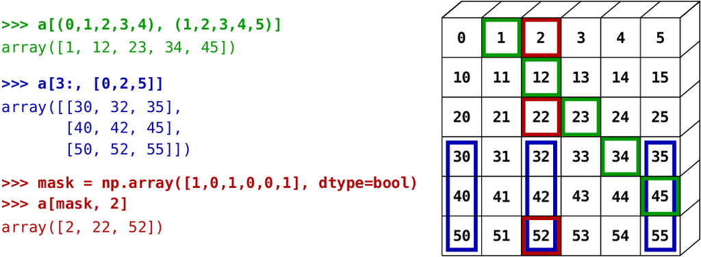

```python
# 행과 열의 index들이 모두 slicing이 아닐 때 - 정수로 이루어진 리스트
a[[0,1,2,3,4], [1,2,3,4,5]]
```

```
array([ 1, 12, 23, 34, 45])
```

```python
a[(0,1,2,3,4), (1,2,3,4,5)]
```

```
array([ 1, 12, 23, 34, 45])
```

```python
# 아래와 같이 해석할 수 있다.
np.array([a[0,1], a[1,2], a[2,3], a[3,4], a[4,5]])
```

```
array([ 1, 12, 23, 34, 45])
```

```python
# slicing과는 다르다.
a[0:5, 1:6]
```

```
array([[ 1,  2,  3,  4,  5],
       [11, 12, 13, 14, 15],
       [21, 22, 23, 24, 25],
       [31, 32, 33, 34, 35],
       [41, 42, 43, 44, 45]])
```

```python
# 행과 열의 index중 하나라도 slicing일 때는 slicing의 규칙을 따른다.
a[3:, [0,2,5]]
```

```
array([[30, 32, 35],
       [40, 42, 45],
       [50, 52, 55]])
```

```python
# Boolean array를 이용할 수도 있다.
mask = np.array([1, 0, 1, 0, 0, 1], dtype=bool)
mask
```

```
array([ True, False,  True, False, False,  True])
```

```python
a[mask, 2]
```

```
array([ 2, 22, 52])
```

```python
row_indices = [1, 2, 3]
a[row_indices]
```

```
array([[10, 11, 12, 13, 14, 15],
       [20, 21, 22, 23, 24, 25],
       [30, 31, 32, 33, 34, 35]])
```

```python
col_indices = [1, 2, -1]             # -1은 마지막 원소를 나타냄
a[row_indices, col_indices]
```

```
array([11, 22, 35])
```

```python
b = np.array([n for n in range(5)])
b
```

```
array([0, 1, 2, 3, 4])
```

```python
row_mask = np.array([True, False, True, False, False])
b[row_mask]
```

```
array([0, 2])
```

```python
# same thing
row_mask = np.array([1,0,1,0,0], dtype=bool)
b[row_mask]
```

```
array([0, 2])
```

```python
x = np.arange(0, 10, 0.5)
x
```

```
array([0. , 0.5, 1. , 1.5, 2. , 2.5, 3. , 3.5, 4. , 4.5, 5. , 5.5, 6. ,
       6.5, 7. , 7.5, 8. , 8.5, 9. , 9.5])
```

```python
x[(5 < x) * (x < 7.5)]
```

```
array([5.5, 6. , 6.5, 7. ])
```

물론 indexing은 대입 연산과 같이 사용할 수 있다.

```python
x[(5 < x) * (x < 7.5)] = -1
print(x)
```

```
[ 0.   0.5  1.   1.5  2.   2.5  3.   3.5  4.   4.5  5.  -1.  -1.  -1.
 -1.   7.5  8.   8.5  9.   9.5]
```

`np.all`은 array나 list의 모든 값이 `True`인지를 체크한다.

```python
np.all([True, True, True])
```

```
True
```

```python
np.all([True, True, True, False])
```

```
False
```

```python
np.all(np.arange(0.5, 10, 0.5) > 0)
```

```
True
```

### Numpy array에서의 복사와 참조

- 성능 향상을 위해 파이썬에서의 많은 경우 복사를 하지 않고 참조를 하는 경우가 많다.

```python
A = np.array([[1, 2], [3, 4]])

A
```

```
array([[1, 2],
       [3, 4]])
```

```python
# B는 A를 참조만 한다.
B = A
```

```python
# B의 변화는 A에도 영향을 미침
B[0,0] = 10

B
```

```
array([[10,  2],
       [ 3,  4]])
```

```python
A
```

```
array([[10,  2],
       [ 3,  4]])
```

- 만약 이런 현상을 원치 않는다면, `.copy()`를 이용하여 복사한다.

```python
C = np.copy(A)
C[0, 0] = -1

C
```

```
array([[-1,  2],
       [ 3,  4]])
```

```python
# A는 바뀌지 않음
A
```

```
array([[10,  2],
       [ 3,  4]])
```

array slicing 또한 기본적으로 참조를 바탕으로 하므로 주의해야 한다.

- view를 제공한다고도 표현한다.

```python
a = np.arange(10)
b = a[::2]
b
```

```
array([0, 2, 4, 6, 8])
```

```python
b[0] = 12
b
```

```
array([12,  2,  4,  6,  8])
```

```python
a   # 주의
```

```
array([12,  1,  2,  3,  4,  5,  6,  7,  8,  9])
```

```python
a = np.arange(10)
c = a[::2].copy()  #복사하여 사용하면
c[0] = 12
c
```

```
array([12,  2,  4,  6,  8])
```

```python
a
```

```
array([0, 1, 2, 3, 4, 5, 6, 7, 8, 9])
```

```python
# Numpy array의 경우
a = np.arange(10)
b = a[:]   # 참조가 발생함
b[0] = 10
a
```

```
array([10,  1,  2,  3,  4,  5,  6,  7,  8,  9])
```

```python
# Python list의 경우는 다르다.
x = list(range(10))
y = x[:]     # list는 이 경우 복사함
y[0] = 10
x
```

```
[0, 1, 2, 3, 4, 5, 6, 7, 8, 9]
```

반면 정수 리스트나 Boolean 리스트를 바탕으로 하는 advanced indexing은 복사를 기본으로 한다.

```python
a = np.arange(10)
d = a[[0,1,2]]
```

```python
d[0] = 10
d
```

```
array([10,  1,  2])
```

```python
# a는 바뀌지 않음
a
```

```
array([0, 1, 2, 3, 4, 5, 6, 7, 8, 9])
```

### numpy와 numpy.linalg를 이용한 선형대수

- numpy는 벡터와 행렬 연산에 있어 강력한 기능을 가지고 있다.
- 벡터 합과 차

```python
a = np.array([3,1,-1])
b = np.arange(3)
c = a + b
d = b - a
```

- 스칼라 곱

```python
4 * a
```

```
array([12,  4, -4])
```

- 제곱합

```python
np.sum(a**2)
```

```
11
```

- dot product

```python
np.dot(a, b)
```

```
-1
```

- 벡터 사이의 거리

```python
np.linalg.norm(a-b)
```

```
4.242640687119285
```

- 벡터 원소별 곱셈

```python
a * b
```

```
array([ 0,  1, -2])
```

- transpose

```python
M = np.array([[1,2], [3,4]])

M
```

```
array([[1, 2],
       [3, 4]])
```

```python
M.T
```

```
array([[1, 3],
       [2, 4]])
```

- 행렬식

```python
np.linalg.det(M)
```

```
-2.0000000000000004
```

- 역행렬

```python
np.linalg.inv(M)
```

```
array([[-2. ,  1. ],
       [ 1.5, -0.5]])
```

- 해 찾기

```python
c = np.array([2,1])
np.linalg.solve(M, c)
```

```
array([-3. ,  2.5])
```

함수 단원에서 살펴보았던 농장 문제를 해 찾기를 이용하여 해결할 수 있다.  
예) 돼지와 닭의 총 수가 20마리이며 총 다리의 숫자가 60개일 때, 돼지와 닭은 각각 몇 마리인가?

- 행렬곱

```python
N = np.array([[-1,1],[2,1]])

N
```

```
array([[-1,  1],
       [ 2,  1]])
```

```python
np.matmul(M,N)
```

```
array([[3, 3],
       [5, 7]])
```

M과 N이 2d-array일 때, 다음과 같이 표현하기도 한다.

```python
M.dot(N)
```

```
array([[3, 3],
       [5, 7]])
```

```python
M @ N
```

```
array([[3, 3],
       [5, 7]])
```

- 행렬의 원소별 곱셈

```python
M * N
```

```
array([[-1,  2],
       [ 6,  4]])
```

### Universal function

numpy에서 제공하는 많은 함수들이 array의 각각의 원소에 적용되는 element-wise 방식을 적용한다.

아래에 그러한 함수 혹은 이항연산자들의 예를 나열하였다. 사용할 때는 `np.`을 붙여 사용한다.

- `abs`, `sqrt`, `exp`, `log`, `sign`, `ceil`, `floor`, `rint`, `cos`, `sin`, `tan`, `isnan`, `isinf`
- `+`, `-`, `*`, `/`, `**`, `<`, `<=`, `>`, `>=`, `==`, `!=`, `&`, `|`

```python
np.sqrt( np.array([1,2,3,4]))
```

```
array([1.        , 1.41421356, 1.73205081, 2.        ])
```

```python
np.sqrt([1,2,3,4])
```

```
array([1.        , 1.41421356, 1.73205081, 2.        ])
```

```python
np.array([True, False, True]) &  np.array([True, True, False])
```

```
array([ True, False, False])
```

### Concatenation

`r_` : 객체를 첫 번째 축을 따라 연결되도록 변환

`c_` : 객체를 두 번째 축을 따라 연결되도록 변환

```python
np.r_[np.array([1,2,3]), 0, 0, np.array([4,5,6])]
```

```
array([1, 2, 3, 0, 0, 4, 5, 6])
```

```python
A = np.array([[1,2],[3,4]])
B = np.array([[5,6],[7,8]])
np.r_[A, B]
```

```
array([[1, 2],
       [3, 4],
       [5, 6],
       [7, 8]])
```

```python
np.c_[np.array([[1],[2],[3]]), np.array([[4],[5],[6]])]
```

```
array([[1, 4],
       [2, 5],
       [3, 6]])
```

```python
A = np.array([[1,2],[3,4]])
B = np.array([[5,6],[7,8]])
np.c_[A, B]
```

```
array([[1, 2, 5, 6],
       [3, 4, 7, 8]])
```